# Analyzing the Converse Relationship of Police Employment and Crime Rates in the 2010s

Aqib Mahfuz

amm198@duke.edu

5/1/2021

# Introduction

Among the several issues facing the United States in the early 2020s, policing and criminal activity have stood out as topics that lead to the most tension and division within the American people. On one hand, campaigns such as “Defund the Police’’ aim to reduce funding to policing institutions (Karma 2020), thereby reducing employment in the sector, while others claim that the nation needs more policing (Phelan 2020), counteracting rising counts of crime with “law and order”. Dispute between the two sides lit ablaze in response to the killing of George Floyd, although fiery debate has been common for at least the past decade. This study looks to analyze two converse relationships at the crux of either side’s argument: the effect of police employment on crime rates, and the effect of crime rate by different demographic groups on future police employment.

### Background

Many speculate about the effectiveness of traditional policing institutions on US crime. The common perception among Americans is that more cops equates to less crime. In fact, according to a Gallup survey conducted prior to the 2020 presidential election, upwards of 80% of US adults said they would like to see as much if not more police presence (Saad 2020), presumably in efforts to reduce crime in their areas. Moreover, the “epidemic of homicidal offenses” in urban areas in the 1980s and 1990s was counteracted with concentrated policing in certain hot spots and led to significant decreases in homicide rates. This strong evidence points to a logical conclusion: more policing reduces the likelihood a crime occurs, especially if the quality of policing isn’t questionably poor. However, the past decade is littered with incidents of police not doing their jobs and their actions resulting in protests, violence, and increased crime rates. Also, in his paper Evidence-Based Crime Prevention, Lawrence W. Sherman notes that “police only make minimal contributions to crime prevention in the context of far more powerful social institutions [like] the family and labor markets.” As a result, alternative methods of keeping the peace have been proposed, such as scaling back officer employment and upping civilian employment for a more community-based approach. To both these points, our experiment will try to analyze the effectiveness of policing.

As a final remark before diving into the study, it is worth emphasizing the importance of effective and just crime prevention solutions in the United States. Citizens should not be extremely worried about violence on a daily basis; this is fundamental to every well-functioning society. As notable criminal sociologist Patrick Sharkey puts it, “Nothing works if public space is unsafe.” This study attempts to use data from the past decade to find trends that can help create solutions to reduce violence in America. As this nation inches closer to a tipping point, finding these solutions is not only an ideal, but a necessity.

### Definition of Terms

- *Officer*: refers to individuals who ordinarily carry a firearm and a badge, have full arrest powers, and are paid from governmental funds
- *Civilian*: refers to individuals employed by a policing institution without receiving formal training and may be working on a volunteer basis or other

Note also that we will often use the terms “crime rate” and “offense rate” interchangeably.

### Hypotheses

**Hypothesis 1: Crimes committed by young, minority offenders is most significant factor in increasing police employment the next year.**

Of all the demographic groups, young and minority offenders are those that are most commonly given attention on news sources and social media. For this reason, we hypothesize that their crime rate will have the most significant relationship with police employment increasing in the next year.

**Hypothesis 2: Increased officer, civilian, and total police employment will all lead to decreases in crime, but civilian employment rates will be the most significant**

The prior evidence supports the idea that more policing reduces crime, but we’d like to test this with our own data. Moreover, a police force with more civilian support being the strongest factor in reducing crime would support the idea that a more community-based approach to violence prevention is the way to go moving forward.

# Procedures and Results

The git repository to this project can be found [here](https://github.com/aqibisbiqa/COVID_Crime).

### Data Collection

Our primary source of data is the FBI’s Crime Data Explorer (CDE), and specifically data reported in the National Incident-Based Reporting System (NIBRS) format.

The CDE has an API from which one can query aggregated national-level data. We used this to acquire police employment rates from 2010 to 2019 of both officers and civilians. We also queried for national crime rates in the past decade; the API provides demographic information (race, age, and sex) for 10 key offenses (“aggravated-assault”, “burglary”, “larceny”, “motor-vehicle-theft”, “homicide”, “rape”, “robbery”, “arson”, “violent-crime”, and “property-crime”). The JSON files returned by these queries were rather messy and required extensive cleaning. Exploratory visualizations are shown in the Appendix.

For state-level crime rate data, we used .csv files that were downloaded for each individual state for each desired year. Within these files were lists of all the incidents, offenses, offenders, and victims (among more) that were recorded in the entire year. Using SQL-like merges and aggregation techniques, we transformed the incident-level data to tables in the same format as the national-level data, except with several more rows as we separate by state. For state-level police employment data, we also downloaded a .csv file from the CDE website that listed police employment data in the same format as the national-level data for all our desired states and years.

Unfortunately, the FBI is conducting an overhaul of their database systems as of March 2021, requiring all states to now report incidents in the NIBRS format (as opposed to the archaic SRS system). This transition has led to limitations in which states we include in our study (as many lack NIBRS data throughout the decade). The list of states that we do include in our analysis are as follows: “AL”, “AZ”, “AR”, “CO”, “CT”, “DE”, “DC”, “ID”, “IL”, “IA”, “KS”, “KY”, “LA”, “ME”, “MA”, “MI”, “MO”, “MT”, “NE”, “NH”, “ND”, “OH”, “OK”, “OR”, “RI”, “SC”, “SD”, “TN”, “TX”, “UT”, “VT”, “VA”, “WA”, “WV”, “WI”.

We also downloaded population data for each state and the nation from the US Census to use in normalizing police employment and crime rates.

### Effect of Police Employment on Crime Rates

#### *Officer Employment Effect*

```
##
## Call:
## lm(formula = offense_rate ~ officer_rate, data = pe_crime_df)
##
## Residuals:
##      Min       1Q   Median       3Q      Max
## -104.379  -48.034   -2.701   32.221  173.818
##
## Coefficients:
##              Estimate Std. Error t value Pr(>|t|)
## (Intercept)   117.033      8.515  13.744  < 2e-16 ***
## officer_rate  -10.703      3.425  -3.125  0.00193 **
## ---
## Signif. codes:  0 '***' 0.001 '**' 0.01 '*' 0.05 '.' 0.1 ' ' 1
##
## Residual standard error: 62.45 on 348 degrees of freedom
## Multiple R-squared:  0.02729,    Adjusted R-squared:  0.02449
## F-statistic: 9.763 on 1 and 348 DF,  p-value: 0.00193
```

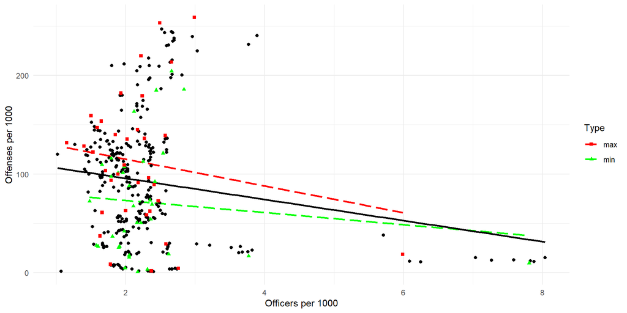

The linear model shows a statistically significant effect and negative correlation between officer rate and offense rate, supporting the claim that more officers leads to less crime. However, our plot shows a cluster of points with high officer rates and low crime rates. This cluster is easily identifiable as the District of Columbia, notorious for its high rate of police employment. If we remove these points from the dataset, we obtain the following:

```
##
## Call:
## lm(formula = offense_rate ~ officer_rate, data = pe_crime_df_no_dc)
##
## Residuals:
##     Min      1Q  Median      3Q     Max
## -95.280 -50.580   3.717  34.777 159.137
##
## Coefficients:
##              Estimate Std. Error t value Pr(>|t|)
## (Intercept)    82.711     15.371   5.381 1.39e-07 ***
## officer_rate    5.686      6.995   0.813    0.417
## ---
## Signif. codes:  0 '***' 0.001 '**' 0.01 '*' 0.05 '.' 0.1 ' ' 1
##
## Residual standard error: 62.66 on 338 degrees of freedom
## Multiple R-squared:  0.001951,   Adjusted R-squared:  -0.001002
## F-statistic: 0.6607 on 1 and 338 DF,  p-value: 0.4169
```

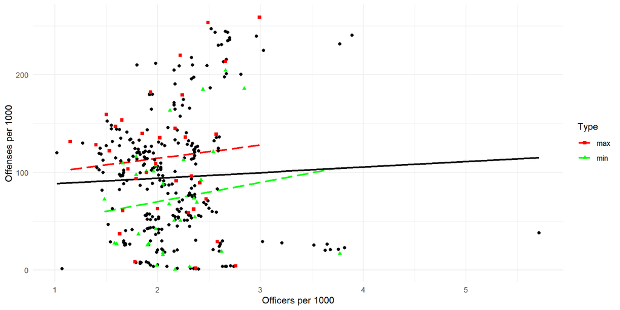

We now see the exact opposite effect from before: officer rate does not have a statistically significant effect on crime rates, but it does seem to be positively correlated. This actually opposes the idea that more officers leads to lower crime. Also, officer rates in isolation are not great predictors of crime rate, as we clearly see several states with similar officer rates have drastically different crime rates.

Note that we also highlighted points that represent years of maximum and minimum crime rates in all the states. In both the case with the District of Columbia and without, we see that the model line is steeper downward with max points as opposed to min points (i.e. the slope is more negative with max points). This leads to a very interesting relationship: in the face of heightened crime, officers have a better ability to reduce crime, while their correlative effect weakens at low crime points.

#### *Civilian Employment Effect*

```
##
## Call:
## lm(formula = offense_rate ~ civilian_rate, data = pe_crime_df)
##
## Residuals:
##      Min       1Q   Median       3Q      Max
## -106.424  -49.307    4.128   36.640  153.693
##
## Coefficients:
##               Estimate Std. Error t value Pr(>|t|)
## (Intercept)     64.807      9.983   6.492 2.93e-10 ***
## civilian_rate   30.418     10.312   2.950  0.00339 **
## ---
## Signif. codes:  0 '***' 0.001 '**' 0.01 '*' 0.05 '.' 0.1 ' ' 1
##
## Residual standard error: 62.54 on 348 degrees of freedom
## Multiple R-squared:  0.0244, Adjusted R-squared:  0.02159
## F-statistic: 8.702 on 1 and 348 DF,  p-value: 0.003394
```

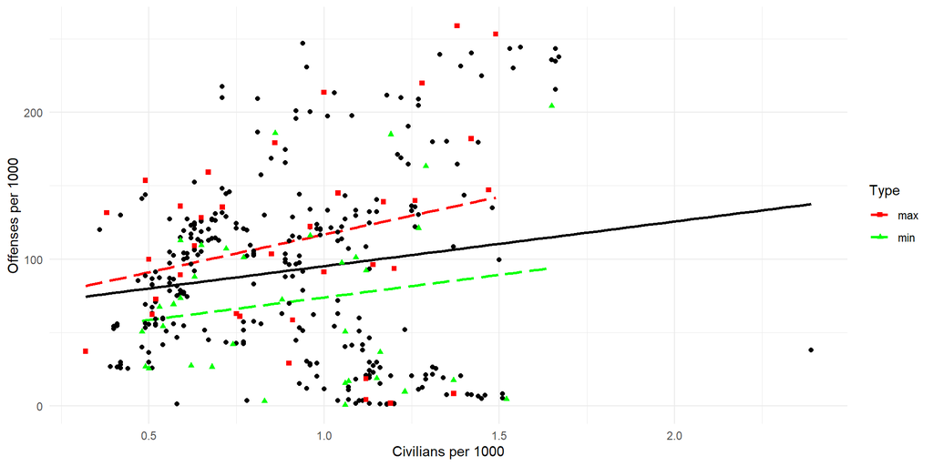

Also of note is that the model for max points now has a higher slope than the model for min points. This implies that civilians in policing institutions do a *worse* job when crime peaks.

#### *Total Employment Effect*

```
##
## Call:
## lm(formula = offense_rate ~ total_rate, data = pe_crime_df)
##
## Residuals:
##      Min       1Q   Median       3Q      Max
## -100.098  -51.453   -0.098   32.794  172.901
##
## Coefficients:
##             Estimate Std. Error t value Pr(>|t|)
## (Intercept)  110.612     10.266  10.775   <2e-16 ***
## total_rate    -5.644      3.031  -1.862   0.0635 .
## ---
## Signif. codes:  0 '***' 0.001 '**' 0.01 '*' 0.05 '.' 0.1 ' ' 1
##
## Residual standard error: 63 on 348 degrees of freedom
## Multiple R-squared:  0.009864,   Adjusted R-squared:  0.007019
## F-statistic: 3.467 on 1 and 348 DF,  p-value: 0.06345
```

```
##
## Call:
## lm(formula = offense_rate ~ total_rate, data = pe_crime_df_no_dc)
##
## Residuals:
##      Min       1Q   Median       3Q      Max
## -111.907  -47.772    5.247   36.192  149.580
##
## Coefficients:
##             Estimate Std. Error t value Pr(>|t|)
## (Intercept)   61.704     15.412   4.003 7.68e-05 ***
## total_rate    10.884      4.931   2.207    0.028 *
## ---
## Signif. codes:  0 '***' 0.001 '**' 0.01 '*' 0.05 '.' 0.1 ' ' 1
##
## Residual standard error: 62.28 on 338 degrees of freedom
## Multiple R-squared:  0.01421,    Adjusted R-squared:  0.01129
## F-statistic: 4.872 on 1 and 338 DF,  p-value: 0.02797
```

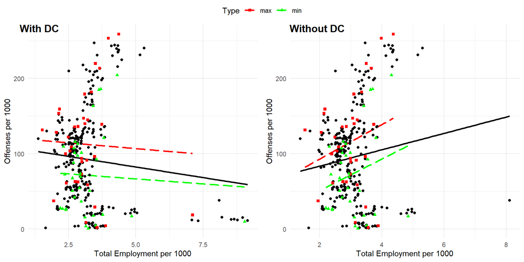

Also, the slopes of the min and max models are nearly even in both the DC and non-DC cases. This suggests that total law enforcement is equally as effective at both low and high points of crime.

### Effect of Crime Rates on Future Police Employment

#### *Race Perspective*

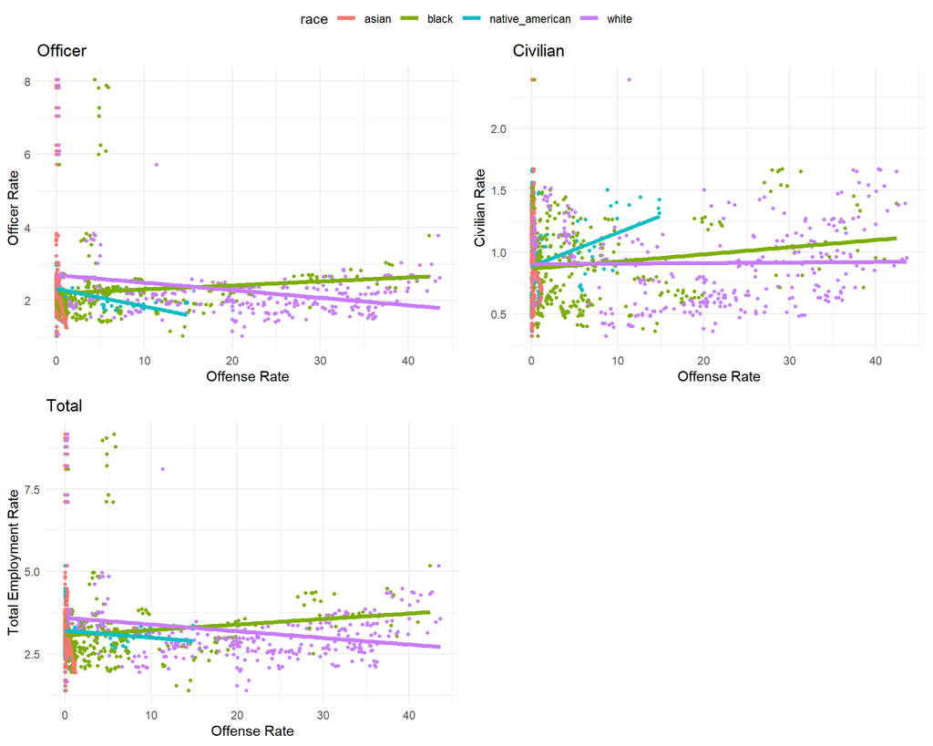

```
##
## Call:
## lm(formula = officer_rate_per_1000 ~ native_american + asian +
##     black + white, data = full_df)
##
## Residuals:
##     Min      1Q  Median      3Q     Max
## -1.6394 -0.4384 -0.1220  0.2400  5.1957
##
## Coefficients:
##                  Estimate Std. Error t value Pr(>|t|)
## (Intercept)      2.709329   0.096176  28.170  < 2e-16 ***
## native_american  0.013583   0.022381   0.607    0.544
## asian           -0.399261   0.266240  -1.500    0.135
## black            0.033485   0.006795   4.928 1.36e-06 ***
## white           -0.030690   0.005832  -5.263 2.66e-07 ***
## ---
## Signif. codes:  0 '***' 0.001 '**' 0.01 '*' 0.05 '.' 0.1 ' ' 1
##
## Residual standard error: 0.8955 on 310 degrees of freedom
## Multiple R-squared:  0.1586, Adjusted R-squared:  0.1478
## F-statistic: 14.61 on 4 and 310 DF,  p-value: 6.031e-11
```

```
##
## Call:
## lm(formula = civilian_rate_per_1000 ~ native_american + asian +
##     black + white, data = full_df)
##
## Residuals:
##      Min       1Q   Median       3Q      Max
## -0.60197 -0.26899 -0.00805  0.21090  1.52863
##
## Coefficients:
##                  Estimate Std. Error t value Pr(>|t|)
## (Intercept)      0.910875   0.032657  27.892  < 2e-16 ***
## native_american  0.039857   0.007600   5.245 2.91e-07 ***
## asian           -0.237820   0.090404  -2.631  0.00895 **
## black            0.010282   0.002307   4.456 1.17e-05 ***
## white           -0.003317   0.001980  -1.675  0.09491 .
## ---
## Signif. codes:  0 '***' 0.001 '**' 0.01 '*' 0.05 '.' 0.1 ' ' 1
##
## Residual standard error: 0.3041 on 310 degrees of freedom
## Multiple R-squared:  0.1349, Adjusted R-squared:  0.1238
## F-statistic: 12.09 on 4 and 310 DF,  p-value: 3.826e-09
```

```
##
## Call:
## lm(formula = total_rate_per_1000 ~ native_american + asian +
##     black + white, data = full_df)
##
## Residuals:
##     Min      1Q  Median      3Q     Max
## -2.0788 -0.4734 -0.1565  0.2624  5.2994
##
## Coefficients:
##                  Estimate Std. Error t value Pr(>|t|)
## (Intercept)      3.620204   0.109122  33.176  < 2e-16 ***
## native_american  0.053440   0.025393   2.104   0.0361 *
## asian           -0.637081   0.302076  -2.109   0.0357 *
## black            0.043767   0.007710   5.677 3.15e-08 ***
## white           -0.034008   0.006617  -5.140 4.88e-07 ***
## ---
## Signif. codes:  0 '***' 0.001 '**' 0.01 '*' 0.05 '.' 0.1 ' ' 1
##
## Residual standard error: 1.016 on 310 degrees of freedom
## Multiple R-squared:  0.1686, Adjusted R-squared:  0.1579
## F-statistic: 15.72 on 4 and 310 DF,  p-value: 1.004e-11
```

Using the four races recorded in the NIBRS format as factors in a linear model, we find that varying results for each type of police employment. Only black and white crime are significant to officer rates, but black crime has a positive correlation while that of white crime is negative. For civilian rates, all the minority races are significant while white crime is not; this implies that people volunteer and join law enforcement mainly in response to minority crime. Lastly, all four races are significant predictors of total employment, but Native American and black crime are positively correlated white Asian and white crime are negatively correlated; one could interpret this as crime by the latter two races being deemed less threatening.

The scatterplots shown also give an idea as to the relationship of crime rates by different races in isolation with future employment rates. As Native American, Asian, and white crime increase, officer rates seem to decrease, while officer rate seems to increase with black crime.

#### *Sex Perspective*

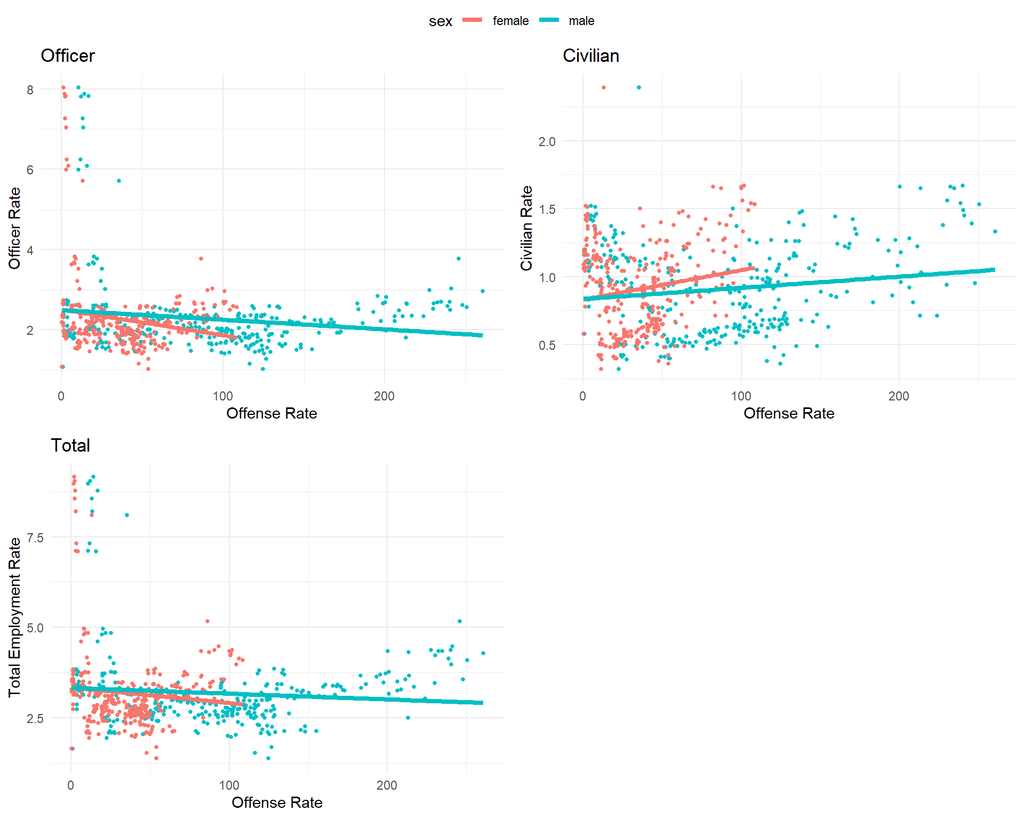

```
##
## Call:
## lm(formula = officer_rate_per_1000 ~ male + female, data = full_df)
##
## Residuals:
##     Min      1Q  Median      3Q     Max
## -1.3719 -0.4554 -0.1962  0.1505  5.4832
##
## Coefficients:
##              Estimate Std. Error t value Pr(>|t|)
## (Intercept)  2.445889   0.095058  25.730  < 2e-16 ***
## male         0.017022   0.007186   2.369  0.01845 *
## female      -0.047214   0.017334  -2.724  0.00682 **
## ---
## Signif. codes:  0 '***' 0.001 '**' 0.01 '*' 0.05 '.' 0.1 ' ' 1
##
## Residual standard error: 0.9501 on 312 degrees of freedom
## Multiple R-squared:  0.04685,    Adjusted R-squared:  0.04074
## F-statistic: 7.668 on 2 and 312 DF,  p-value: 0.000561
```

```
##
## Call:
## lm(formula = civilian_rate_per_1000 ~ male + female, data = full_df)
##
## Residuals:
##      Min       1Q   Median       3Q      Max
## -0.62297 -0.27854 -0.01166  0.24312  1.53224
##
## Coefficients:
##              Estimate Std. Error t value Pr(>|t|)
## (Intercept)  0.847493   0.031943  26.532   <2e-16 ***
## male        -0.004470   0.002415  -1.851   0.0651 .
## female       0.012864   0.005825   2.209   0.0279 *
## ---
## Signif. codes:  0 '***' 0.001 '**' 0.01 '*' 0.05 '.' 0.1 ' ' 1
##
## Residual standard error: 0.3193 on 312 degrees of freedom
## Multiple R-squared:  0.04025,    Adjusted R-squared:  0.0341
## F-statistic: 6.542 on 2 and 312 DF,  p-value: 0.001648
```

```
##
## Call:
## lm(formula = total_rate_per_1000 ~ male + female, data = full_df)
##
## Residuals:
##     Min      1Q  Median      3Q     Max
## -1.6407 -0.5780 -0.2311  0.2655  5.7507
##
## Coefficients:
##              Estimate Std. Error t value Pr(>|t|)
## (Intercept)  3.293382   0.110171  29.893   <2e-16 ***
## male         0.012552   0.008328   1.507   0.1328
## female      -0.034349   0.020090  -1.710   0.0883 .
## ---
## Signif. codes:  0 '***' 0.001 '**' 0.01 '*' 0.05 '.' 0.1 ' ' 1
##
## Residual standard error: 1.101 on 312 degrees of freedom
## Multiple R-squared:  0.01724,    Adjusted R-squared:  0.01095
## F-statistic: 2.737 on 2 and 312 DF,  p-value: 0.06629
```

#### *Age Perspective*

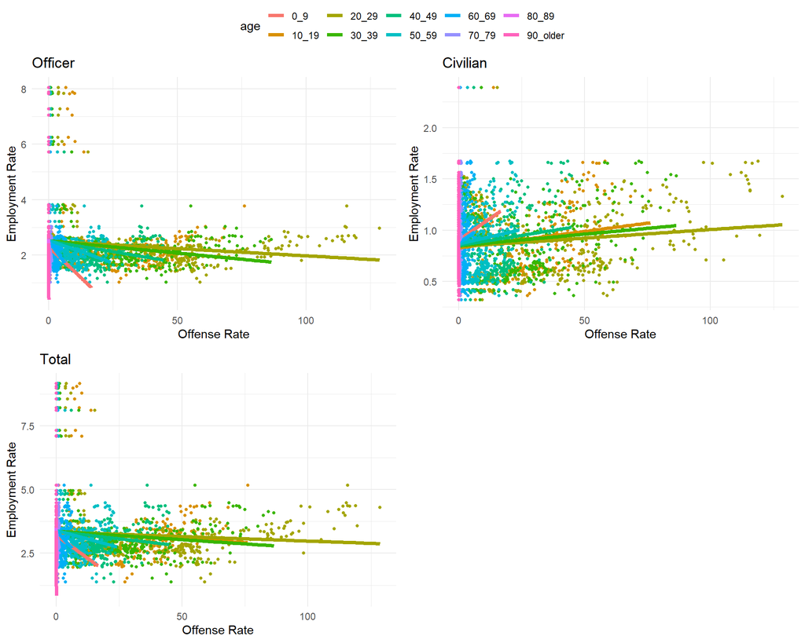

```
##
## Call:
## lm(formula = officer_rate_per_1000 ~ `0_9` + `10_19` + `20_29` +
##     `30_39` + `40_49` + `50_59` + `60_69` + `70_79` + `80_89` +
##     `90_older`, data = full_df)
##
## Residuals:
##     Min      1Q  Median      3Q     Max
## -1.5087 -0.4720 -0.1924  0.1460  5.4763
##
## Coefficients:
##              Estimate Std. Error t value Pr(>|t|)
## (Intercept)  2.575923   0.100132  25.725   <2e-16 ***
## `0_9`       -0.039100   0.058657  -0.667    0.506
## `10_19`     -0.008269   0.009836  -0.841    0.401
## `20_29`      0.016216   0.012407   1.307    0.192
## `30_39`     -0.019317   0.018404  -1.050    0.295
## `40_49`      0.014135   0.035097   0.403    0.687
## `50_59`     -0.070809   0.073396  -0.965    0.335
## `60_69`      0.152956   0.299225   0.511    0.610
## `70_79`      0.422418   1.068506   0.395    0.693
## `80_89`     -3.269263   2.168879  -1.507    0.133
## `90_older`  -2.364168   5.235902  -0.452    0.652
## ---
## Signif. codes:  0 '***' 0.001 '**' 0.01 '*' 0.05 '.' 0.1 ' ' 1
##
## Residual standard error: 0.9528 on 304 degrees of freedom
## Multiple R-squared:  0.06595,    Adjusted R-squared:  0.03522
## F-statistic: 2.146 on 10 and 304 DF,  p-value: 0.02102
```

```
##
## Call:
## lm(formula = civilian_rate_per_1000 ~ `0_9` + `10_19` + `20_29` +
##     `30_39` + `40_49` + `50_59` + `60_69` + `70_79` + `80_89` +
##     `90_older`, data = full_df)
##
## Residuals:
##      Min       1Q   Median       3Q      Max
## -0.64326 -0.23136 -0.04461  0.23438  1.51870
##
## Coefficients:
##              Estimate Std. Error t value Pr(>|t|)
## (Intercept)  0.863691   0.032562  26.524   <2e-16 ***
## `0_9`        0.001558   0.019075   0.082   0.9350
## `10_19`      0.005840   0.003199   1.826   0.0688 .
## `20_29`     -0.003114   0.004035  -0.772   0.4408
## `30_39`      0.017670   0.005985   2.952   0.0034 **
## `40_49`     -0.006873   0.011413  -0.602   0.5475
## `50_59`     -0.005112   0.023868  -0.214   0.8306
## `60_69`     -0.091951   0.097307  -0.945   0.3454
## `70_79`     -0.047873   0.347474  -0.138   0.8905
## `80_89`     -0.708047   0.705312  -1.004   0.3162
## `90_older`  -3.554854   1.702697  -2.088   0.0377 *
## ---
## Signif. codes:  0 '***' 0.001 '**' 0.01 '*' 0.05 '.' 0.1 ' ' 1
##
## Residual standard error: 0.3099 on 304 degrees of freedom
## Multiple R-squared:  0.1192, Adjusted R-squared:  0.09018
## F-statistic: 4.112 on 10 and 304 DF,  p-value: 2.469e-05
```

```
##
## Call:
## lm(formula = total_rate_per_1000 ~ `0_9` + `10_19` + `20_29` +
##     `30_39` + `40_49` + `50_59` + `60_69` + `70_79` + `80_89` +
##     `90_older`, data = full_df)
##
## Residuals:
##     Min      1Q  Median      3Q     Max
## -1.7940 -0.5666 -0.1860  0.2481  5.7297
##
## Coefficients:
##              Estimate Std. Error t value Pr(>|t|)
## (Intercept)  3.439614   0.114532  30.032   <2e-16 ***
## `0_9`       -0.037542   0.067093  -0.560    0.576
## `10_19`     -0.002429   0.011250  -0.216    0.829
## `20_29`      0.013103   0.014191   0.923    0.357
## `30_39`     -0.001647   0.021051  -0.078    0.938
## `40_49`      0.007262   0.040144   0.181    0.857
## `50_59`     -0.075921   0.083951  -0.904    0.367
## `60_69`      0.061005   0.342258   0.178    0.859
## `70_79`      0.374544   1.222172   0.306    0.759
## `80_89`     -3.977310   2.480794  -1.603    0.110
## `90_older`  -5.919023   5.988898  -0.988    0.324
## ---
## Signif. codes:  0 '***' 0.001 '**' 0.01 '*' 0.05 '.' 0.1 ' ' 1
##
## Residual standard error: 1.09 on 304 degrees of freedom
## Multiple R-squared:  0.06199,    Adjusted R-squared:  0.03113
## F-statistic: 2.009 on 10 and 304 DF,  p-value: 0.03215
```

#### *Offense Perspective*

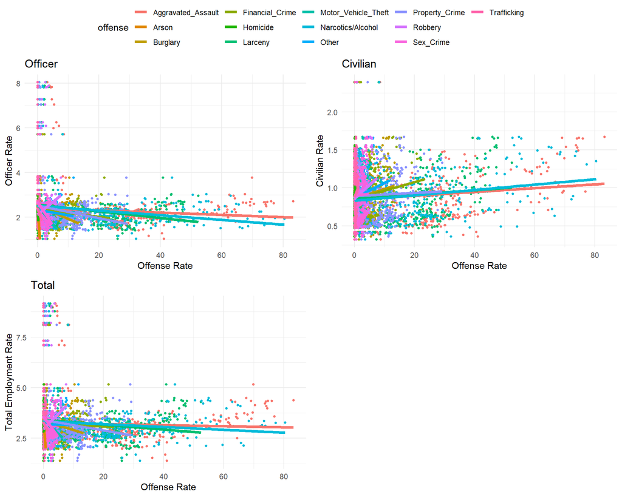

```
##
## Call:
## lm(formula = officer_rate_per_1000 ~ Other + Arson + Aggravated_Assault +
##     Financial_Crime + Burglary + Property_Crime + `Narcotics/Alcohol` +
##     Homicide + Trafficking + Larceny + Motor_Vehicle_Theft +
##     Sex_Crime + Robbery, data = full_df)
##
## Residuals:
##     Min      1Q  Median      3Q     Max
## -1.5410 -0.4561 -0.1456  0.3098  4.2484
##
## Coefficients:
##                      Estimate Std. Error t value Pr(>|t|)
## (Intercept)          2.606090   0.091435  28.502  < 2e-16 ***
## Other               -0.236784   0.068023  -3.481 0.000574 ***
## Arson                0.439232   0.706245   0.622 0.534462
## Aggravated_Assault   0.021782   0.009261   2.352 0.019321 *
## Financial_Crime      0.070520   0.037088   1.901 0.058200 .
## Burglary            -0.200884   0.054878  -3.661 0.000297 ***
## Property_Crime       0.017941   0.030513   0.588 0.556977
## `Narcotics/Alcohol`  0.014475   0.005941   2.437 0.015409 *
## Homicide            -2.508074   1.659034  -1.512 0.131642
## Trafficking         -0.121114   0.317670  -0.381 0.703282
## Larceny             -0.006490   0.016690  -0.389 0.697670
## Motor_Vehicle_Theft  0.084431   0.075357   1.120 0.263428
## Sex_Crime           -0.481002   0.101945  -4.718 3.65e-06 ***
## Robbery              0.448097   0.056792   7.890 5.64e-14 ***
## ---
## Signif. codes:  0 '***' 0.001 '**' 0.01 '*' 0.05 '.' 0.1 ' ' 1
##
## Residual standard error: 0.8239 on 301 degrees of freedom
## Multiple R-squared:  0.3085, Adjusted R-squared:  0.2786
## F-statistic: 10.33 on 13 and 301 DF,  p-value: < 2.2e-16
```

```
##
## Call:
## lm(formula = civilian_rate_per_1000 ~ Other + Arson + Aggravated_Assault +
##     Financial_Crime + Burglary + Property_Crime + `Narcotics/Alcohol` +
##     Homicide + Trafficking + Larceny + Motor_Vehicle_Theft +
##     Sex_Crime + Robbery, data = full_df)
##
## Residuals:
##      Min       1Q   Median       3Q      Max
## -0.60550 -0.18452  0.00642  0.17915  1.52028
##
## Coefficients:
##                      Estimate Std. Error t value Pr(>|t|)
## (Intercept)          0.917089   0.031125  29.464  < 2e-16 ***
## Other               -0.083254   0.023156  -3.595 0.000378 ***
## Arson                0.543360   0.240413   2.260 0.024529 *
## Aggravated_Assault   0.003506   0.003153   1.112 0.266983
## Financial_Crime      0.052205   0.012625   4.135 4.61e-05 ***
## Burglary             0.017760   0.018681   0.951 0.342526
## Property_Crime      -0.042496   0.010387  -4.091 5.51e-05 ***
## `Narcotics/Alcohol`  0.011245   0.002022   5.561 5.94e-08 ***
## Homicide            -1.434052   0.564752  -2.539 0.011612 *
## Trafficking          0.156846   0.108138   1.450 0.147981
## Larceny              0.000219   0.005681   0.039 0.969274
## Motor_Vehicle_Theft  0.066561   0.025652   2.595 0.009929 **
## Sex_Crime           -0.211670   0.034703  -6.099 3.26e-09 ***
## Robbery              0.079757   0.019333   4.126 4.79e-05 ***
## ---
## Signif. codes:  0 '***' 0.001 '**' 0.01 '*' 0.05 '.' 0.1 ' ' 1
##
## Residual standard error: 0.2805 on 301 degrees of freedom
## Multiple R-squared:  0.2854, Adjusted R-squared:  0.2545
## F-statistic: 9.248 on 13 and 301 DF,  p-value: 4.461e-16
```

```
##
## Call:
## lm(formula = total_rate_per_1000 ~ Other + Arson + Aggravated_Assault +
##     Financial_Crime + Burglary + Property_Crime + `Narcotics/Alcohol` +
##     Homicide + Trafficking + Larceny + Motor_Vehicle_Theft +
##     Sex_Crime + Robbery, data = full_df)
##
## Residuals:
##     Min      1Q  Median      3Q     Max
## -1.8799 -0.4741 -0.1306  0.3230  4.9549
##
## Coefficients:
##                      Estimate Std. Error t value Pr(>|t|)
## (Intercept)          3.523180   0.102570  34.349  < 2e-16 ***
## Other               -0.320038   0.076307  -4.194 3.61e-05 ***
## Arson                0.982592   0.792255   1.240 0.215850
## Aggravated_Assault   0.025288   0.010389   2.434 0.015512 *
## Financial_Crime      0.122725   0.041605   2.950 0.003429 **
## Burglary            -0.183124   0.061562  -2.975 0.003171 **
## Property_Crime      -0.024554   0.034229  -0.717 0.473712
## `Narcotics/Alcohol`  0.025721   0.006664   3.859 0.000139 ***
## Homicide            -3.942126   1.861079  -2.118 0.034978 *
## Trafficking          0.035733   0.356357   0.100 0.920195
## Larceny             -0.006271   0.018722  -0.335 0.737913
## Motor_Vehicle_Theft  0.150993   0.084534   1.786 0.075077 .
## Sex_Crime           -0.692672   0.114360  -6.057 4.13e-09 ***
## Robbery              0.527854   0.063708   8.285 3.92e-15 ***
## ---
## Signif. codes:  0 '***' 0.001 '**' 0.01 '*' 0.05 '.' 0.1 ' ' 1
##
## Residual standard error: 0.9243 on 301 degrees of freedom
## Multiple R-squared:  0.332,  Adjusted R-squared:  0.3032
## F-statistic: 11.51 on 13 and 301 DF,  p-value: < 2.2e-16
```

## 1. Visualizing Police Employment

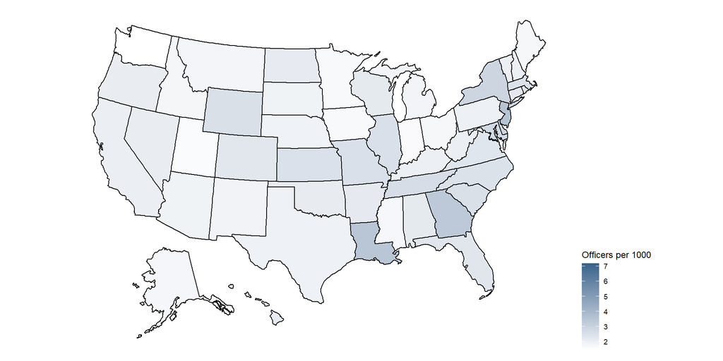

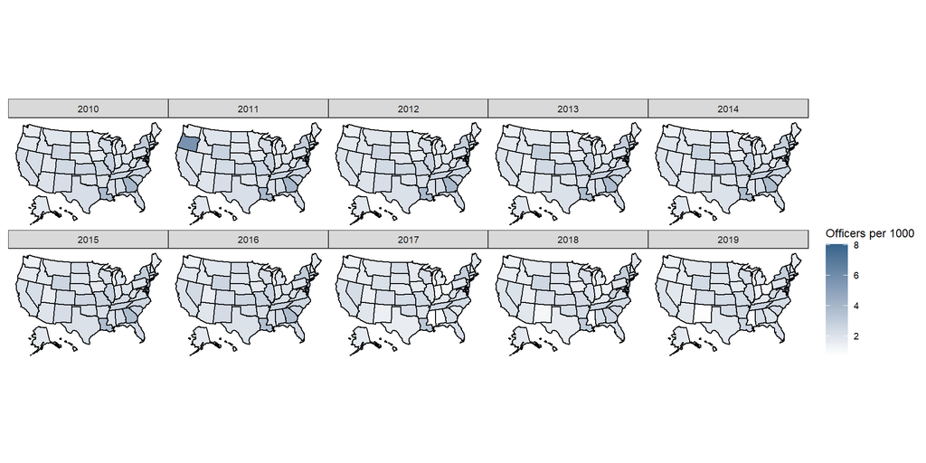

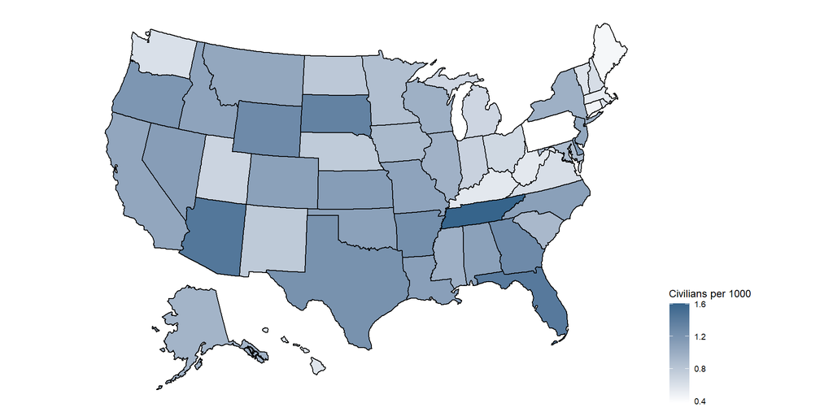

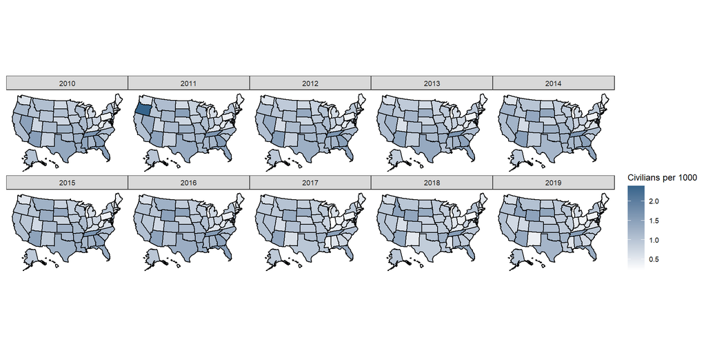

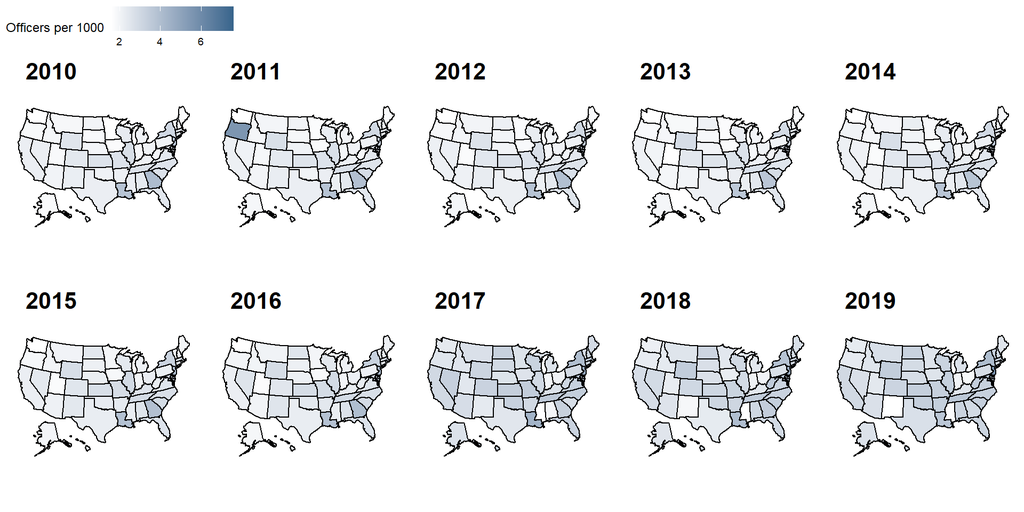

**Fig. 1:** Police employment per 1000 citizens across US from 2010 to 2019. Darker tones indicate higher rates of employment.

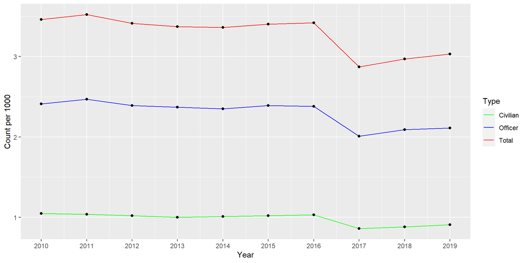

**Fig 2:** Police employment per 1000 citizens on national scale.

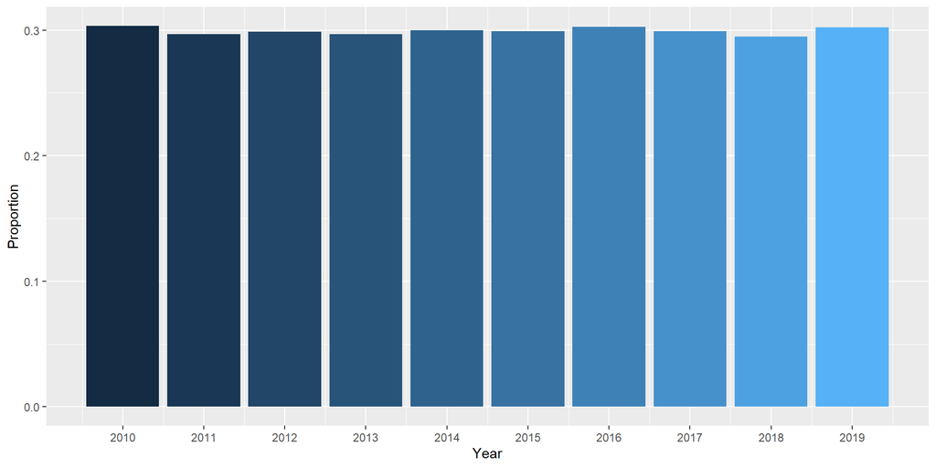

**Fig 3:** National proportion of civilians in law enforcement

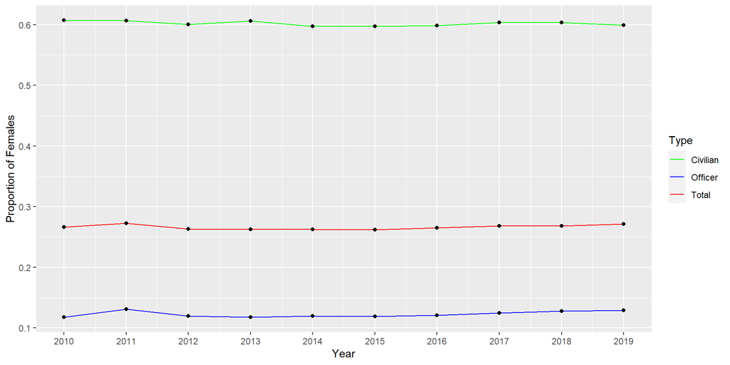

**Fig 4:** National proportion of females in law enforcement

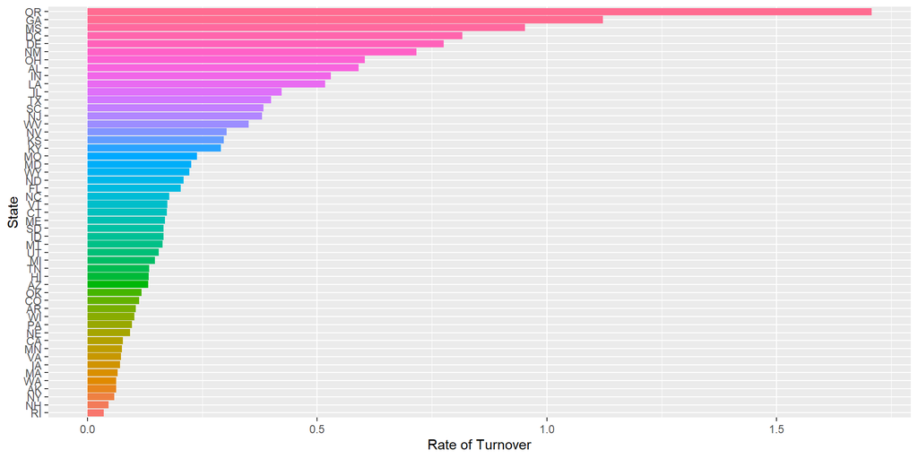

## 2. Visualizing Crime Rates

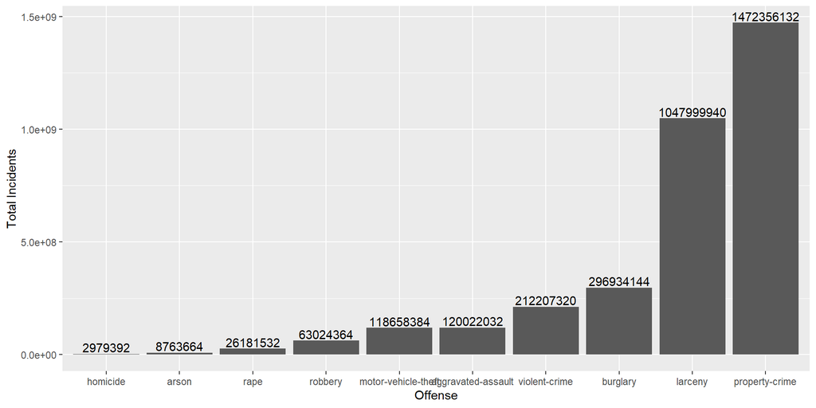

**Fig 6:** Most common crimes committed from 2010-2019

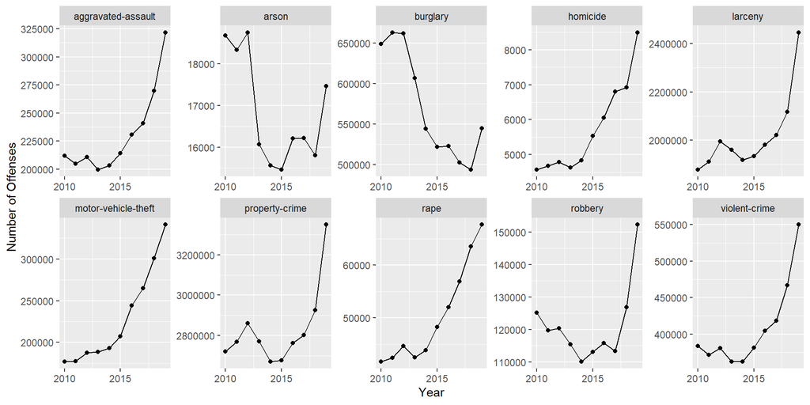

**Fig 7:** Total Number of Offenses by Crime

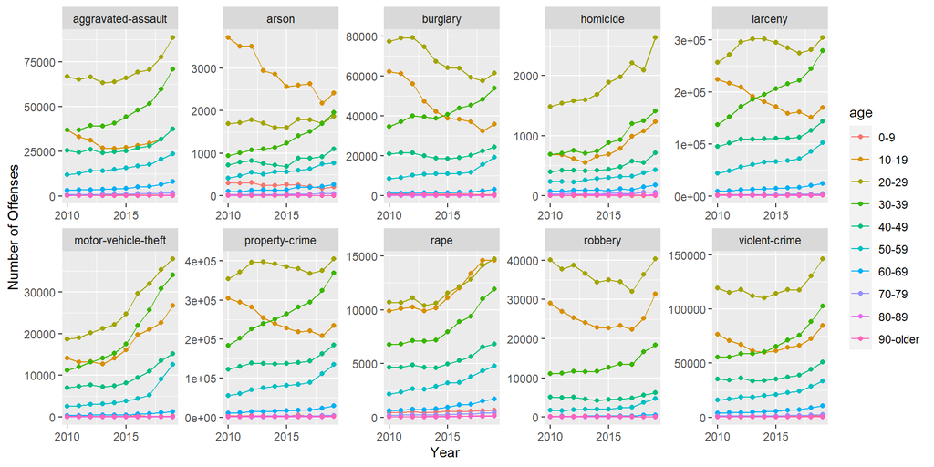

**Fig 8:** Offenses by crime and age group

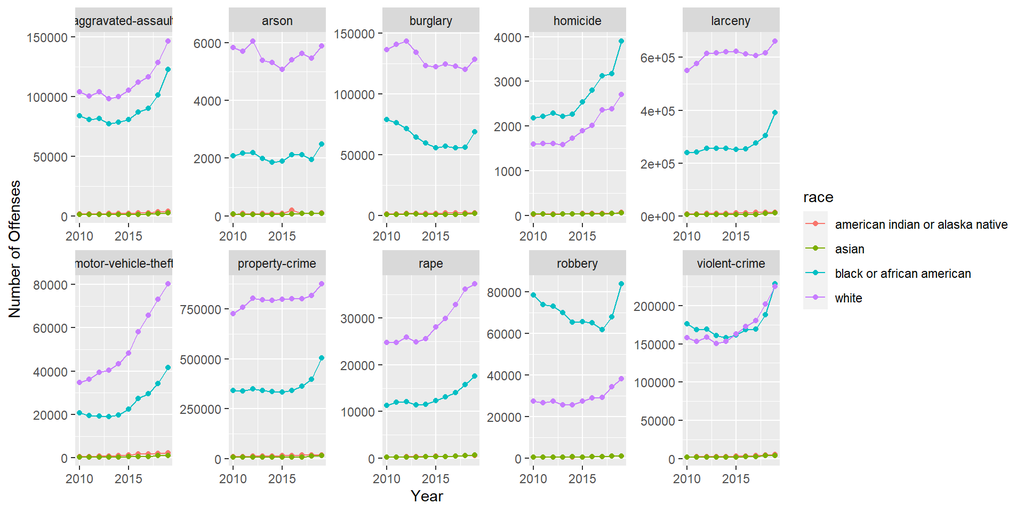

**Fig 9:** Offenses by crime and race

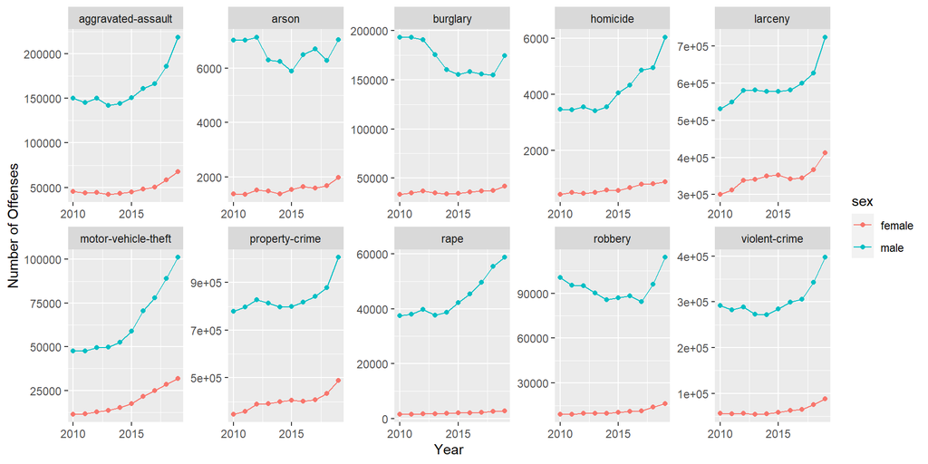

**Fig 10:** Offenses by crime and sex